# Effect of Workplace Smoking Bans on Smoking Behaviour: A Logistic Regression Analysis

# 6 Preliminary Analysis: Chi-Square Test

Before fitting the logistic regression model, a Chi-square test of independence is conducted to examine the bivariate association between workplace smoking ban (`ban`) and smoking status (`smoker`).

## 6.1 Chi-Square Assumption: Expected Cell Frequencies ≥ 5

```r
ct_chisq <- table(Smoker = data$smoker, Ban = data$ban)
expected <- chisq.test(ct_chisq)$expected
kable(round(expected, 1),
      caption = "Table 7: Expected Cell Frequencies (Chi-Square Assumption)") %>%
  kable_styling(bootstrap_options = c("striped", "hover"), full_width = FALSE)
```

Table 7: Expected Cell Frequencies (Chi-Square Assumption)

|  | no | yes |
| --- | --- | --- |
| no | 2956.5 | 4620.5 |
| yes | 945.5 | 1477.5 |

**Result:** All expected cell frequencies are well above 5. The Chi-square assumption is **satisfied**.

## 6.2 Chi-Square Test Results

```r
chisq_result <- chisq.test(ct_chisq)
print(chisq_result)
```

```
##
##  Pearson's Chi-squared test with Yates' continuity correction
##
## data:  ct_chisq
## X-squared = 77.54, df = 1, p-value < 2.2e-16
```

```r
# Effect size: Cramér's V
n_total   <- sum(ct_chisq)
cramer_v  <- sqrt(chisq_result$statistic / (n_total * (min(dim(ct_chisq)) - 1)))
cat("\nCramer's V (effect size):", round(cramer_v, 4), "\n")
```

```
##
## Cramer's V (effect size): 0.0881
```

**Interpretation:** The Chi-square test examines whether there is a statistically significant association between workplace smoking bans and smoking status.

- **If p < 0.05:** There is a statistically significant association between having a workplace smoking ban and smoking status. Individuals subject to a ban are significantly more or less likely to be smokers.
- **Cramér’s V** measures the strength of the association: values near 0 indicate a weak association; values above 0.3 indicate a moderate-to-strong association.
- **Important limitation:** The Chi-square test only tells us *whether* an association exists, not *how much* the ban affects smoking probability after accounting for other factors. This is why logistic regression is also required.

# 7 Binary Logistic Regression

## 7.1 Fitting the Logistic Regression Model

```r
# Final model with ordered education treated as linear (polynomial contrasts)
model <- glm(smoker ~ ban + age + education + afam + hispanic + gender,
             data   = data,
             family = binomial(link = "logit"))

# Model summary
summary(model)
```

```
##
## Call:
## glm(formula = smoker ~ ban + age + education + afam + hispanic +
##     gender, family = binomial(link = "logit"), data = data)
##
## Coefficients:
##               Estimate Std. Error z value Pr(>|z|)
## (Intercept)  -0.684923   0.090476  -7.570 3.73e-14 ***
## banyes       -0.250735   0.049164  -5.100 3.40e-07 ***
## age          -0.007452   0.001987  -3.751 0.000176 ***
## education.L  -1.568712   0.087036 -18.024  < 2e-16 ***
## education.Q  -0.119217   0.076413  -1.560 0.118721
## education.C   0.084125   0.063132   1.333 0.182682
## education^4   0.145737   0.050744   2.872 0.004079 **
## afamyes      -0.149472   0.089994  -1.661 0.096732 .
## hispanicyes  -0.584845   0.083085  -7.039 1.93e-12 ***
## genderfemale -0.188720   0.049105  -3.843 0.000121 ***
## ---
## Signif. codes:  0 '***' 0.001 '**' 0.01 '*' 0.05 '.' 0.1 ' ' 1
##
## (Dispersion parameter for binomial family taken to be 1)
##
##     Null deviance: 11074  on 9999  degrees of freedom
## Residual deviance: 10502  on 9990  degrees of freedom
## AIC: 10522
##
## Number of Fisher Scoring iterations: 4
```

## 7.2 Odds Ratios and 95% Confidence Intervals

```r
# Compute Odds Ratios and 95% CI
OR    <- exp(coef(model))
CI    <- exp(confint(model))
p_val <- summary(model)$coefficients[, 4]

results_table <- data.frame(
  Predictor     = names(OR),
  Odds_Ratio    = round(OR, 3),
  CI_Lower      = round(CI[, 1], 3),
  CI_Upper      = round(CI[, 2], 3),
  P_Value       = round(p_val, 4),
  Significance  = ifelse(p_val < 0.001, "***",
                  ifelse(p_val < 0.01, "**",
                  ifelse(p_val < 0.05, "*", "ns")))
)

kable(results_table,
      caption = "Table 8: Logistic Regression Results — Odds Ratios and 95% Confidence Intervals",
      row.names = FALSE) %>%
  kable_styling(bootstrap_options = c("striped", "hover", "bordered"),
                full_width = TRUE, font_size = 13) %>%
  add_footnote("* p<0.05  ** p<0.01  *** p<0.001  ns = not significant")
```

Table 8: Logistic Regression Results — Odds Ratios and 95% Confidence Intervals

| Predictor | Odds_Ratio | CI_Lower | CI_Upper | P_Value | Significance |
| --- | --- | --- | --- | --- | --- |
| (Intercept) | 0.504 | 0.422 | 0.602 | 0.0000 | *** |
| banyes | 0.778 | 0.707 | 0.857 | 0.0000 | *** |
| age | 0.993 | 0.989 | 0.996 | 0.0002 | *** |
| education.L | 0.208 | 0.175 | 0.247 | 0.0000 | *** |
| education.Q | 0.888 | 0.763 | 1.029 | 0.1187 | ns |
| education.C | 1.088 | 0.961 | 1.231 | 0.1827 | ns |
| education^4 | 1.157 | 1.048 | 1.278 | 0.0041 | ** |
| afamyes | 0.861 | 0.720 | 1.025 | 0.0967 | ns |
| hispanicyes | 0.557 | 0.473 | 0.655 | 0.0000 | *** |
| genderfemale | 0.828 | 0.752 | 0.912 | 0.0001 | *** |

<sup>a</sup> * p<0.05 ** p<0.01 *** p<0.001 ns = not significant

## 7.3 Model Fit Statistics

```r
# Nagelkerke Pseudo R-squared
pseudo_r2 <- PseudoR2(model, which = c("McFadden", "Nagelkerke", "CoxSnell"))
cat("Pseudo R-squared Values:\n")
```

```
## Pseudo R-squared Values:
```

```r
print(round(pseudo_r2, 4))
```

```
##   McFadden Nagelkerke   CoxSnell
##     0.0517     0.0830     0.0556
```

```r
# Hosmer-Lemeshow Goodness-of-Fit Test
# Null hypothesis: the model fits the data well (p > 0.05 = good fit)
hl_test <- hoslem.test(as.numeric(data$smoker) - 1, fitted(model), g = 10)
print(hl_test)
```

```
##
##  Hosmer and Lemeshow goodness of fit (GOF) test
##
## data:  as.numeric(data$smoker) - 1, fitted(model)
## X-squared = 6.488, df = 8, p-value = 0.5927
```

```r
# Model AIC (lower = better fit)
cat("\nAIC:", round(AIC(model), 2), "\n")
```

```
##
## AIC: 10522.19
```

```r
cat("Null Deviance:", round(model$null.deviance, 2), "\n")
```

```
## Null Deviance: 11074.33
```

```r
cat("Residual Deviance:", round(model$deviance, 2), "\n")
```

```
## Residual Deviance: 10502.19
```

```r
cat("Deviance Reduction:", round(model$null.deviance - model$deviance, 2), "\n")
```

```
## Deviance Reduction: 572.14
```

# 8 Visualisation of Regression Results

## 8.1 Visualisation 5: Odds Ratio Forest Plot

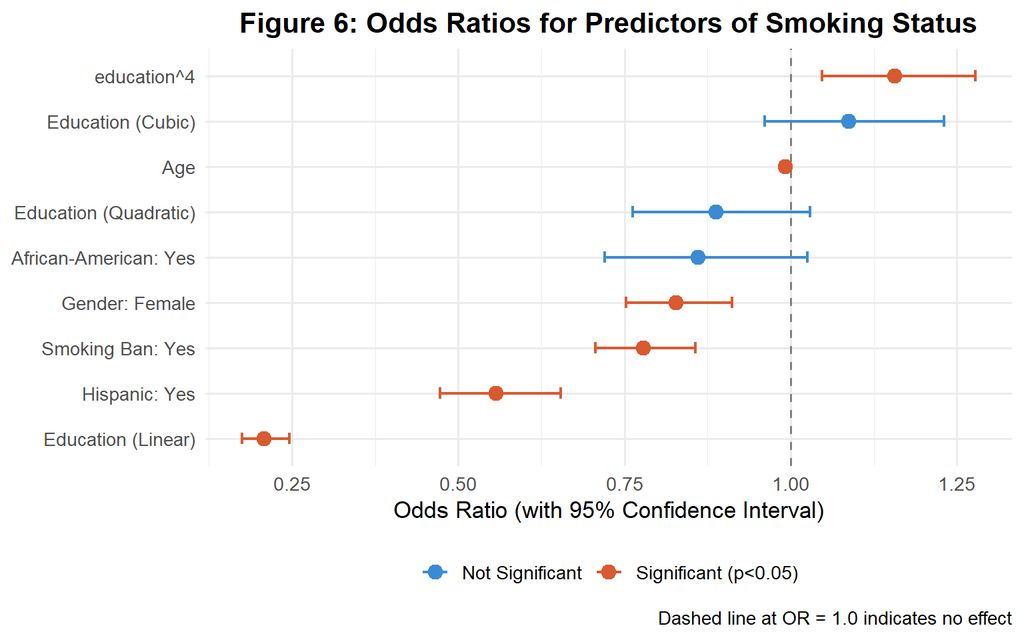

```r
tidy_model <- tidy(model, conf.int = TRUE, exponentiate = TRUE)

# Exclude intercept for plotting
tidy_plot <- tidy_model %>%
  filter(term != "(Intercept)") %>%
  mutate(
    significant = ifelse(p.value < 0.05, "Significant (p<0.05)", "Not Significant"),
    term = case_match(term,
      "banyes"        ~ "Smoking Ban: Yes",
      "age"           ~ "Age",
      "education.L"   ~ "Education (Linear)",
      "education.Q"   ~ "Education (Quadratic)",
      "education.C"   ~ "Education (Cubic)",
      "afamyes"       ~ "African-American: Yes",
      "hispanicyes"   ~ "Hispanic: Yes",
      "genderfemale"  ~ "Gender: Female",
      .default = term
    )
  )

ggplot(tidy_plot, aes(x = estimate, y = reorder(term, estimate),
                       xmin = conf.low, xmax = conf.high,
                       colour = significant)) +
  geom_vline(xintercept = 1, linetype = "dashed", colour = "grey50") +
  geom_errorbarh(height = 0.25, linewidth = 0.8) +
  geom_point(size = 3.5) +
  scale_colour_manual(values = c("Significant (p<0.05)" = "#D85A30",
                                  "Not Significant"       = "#3B8BD4")) +
  labs(
    title   = "Figure 6: Odds Ratios for Predictors of Smoking Status",
    x       = "Odds Ratio (with 95% Confidence Interval)",
    y       = NULL,
    colour  = NULL,
    caption = "Dashed line at OR = 1.0 indicates no effect"
  ) +
  theme_minimal(base_size = 13) +
  theme(
    plot.title  = element_text(face = "bold", hjust = 0.5),
    legend.position = "bottom"
  )
```

**Interpretation:** In Figure 6, predictors with confidence intervals that do not cross the vertical dashed line at OR = 1.0 are statistically significant. Predictors with OR < 1 reduce the odds of being a smoker; predictors with OR > 1 increase the odds.